# World Bank Agriculture Analysis

Robin Billinger

2025-01-16

## Introduction

World Bank Indicators

| Variable | Indicator Name | Definition |
| --- | --- | --- |
| AG.LND.AGRI.ZS | Agricultural land (% of land area) | Agricultural land refers to the share of land area that is arable, under permanent crops, and under permanent pastures. Arable land includes land defined by the FAO as land under temporary crops (doub… |
| AG.SRF.TOTL.K2 | Surface area (sq. km) | Surface area is a country’s total area, including areas under inland bodies of water and some coastal waterways. |
| EN.GHG.CO2.MT.CE.AR5 | Carbon dioxide (CO2) emissions (total) excluding LULUCF (Mt CO2e) | A measure of annual emissions of carbon dioxide (CO2), one of the six Kyoto greenhouse gases (GHG), from the building sector (subsector of the energy sector) including IPCC 2006 codes 1.A.4 Residentia… |

## Agenda

1.) Percentage of agricultural land and CO2 emissions per capita  
1.1.) Heat map of CO2 emissions  
1.2.) Boxplot of CO2 emissions  
1.3.) Point-line plot of agricultural land with faceted countries  
1.4.) Boxplot of agricultural land  
1.5.) Scatter plot of interested variables  
1.6.) Point-line plot of CO2 emissions with faceted countries and color scale  
1.7.) Point-line plot of interested variables with faceted countries; normalized  
2.) Summary and Outlook

#### 1.1. Heat map of CO2 emissions

Starting with the distribution of the CO2 emissions, we get the following information.

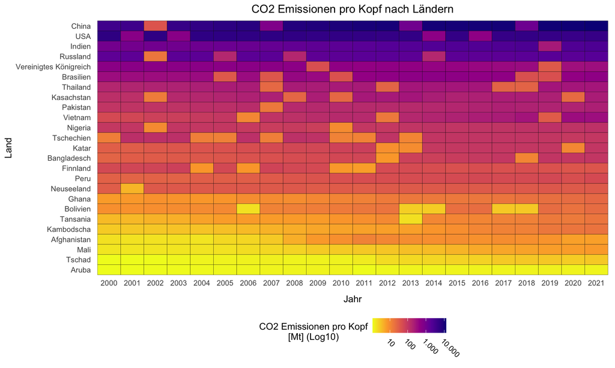

```
##      Min.   1st Qu.    Median      Mean   3rd Qu.      Max.
##     0.246     8.782    50.328   672.243   232.015 12717.655
```

It appears that occasionally there are immense differences within countries’ values from one year to another, displayed by clear jumps in the sequential color scale. After further investigation of this phenomenon and consultation with our supervisors, we came to the conclusion that the false values originate from database-caused mishandle during the data set’s download. Moving forward, we accept these anomalies and handle them as the error-produced outliers as they are.

#### 1.2. Boxplot of CO2 emissions

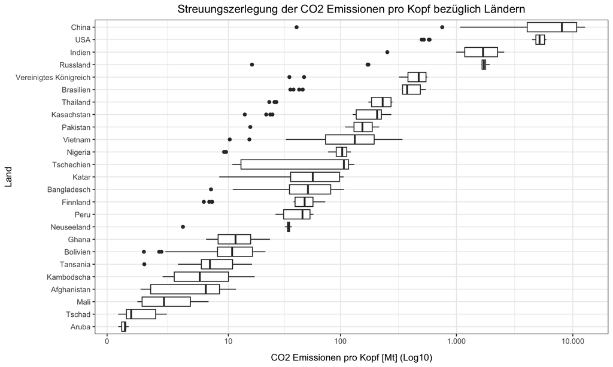

```
## Streuung zwischen den Ländern:  2787843
```

#### 1.3. Point-line plot of agricultural land with faceted countries

Furthermore, the distribution of the percentage of agricultural land delivers the following information.

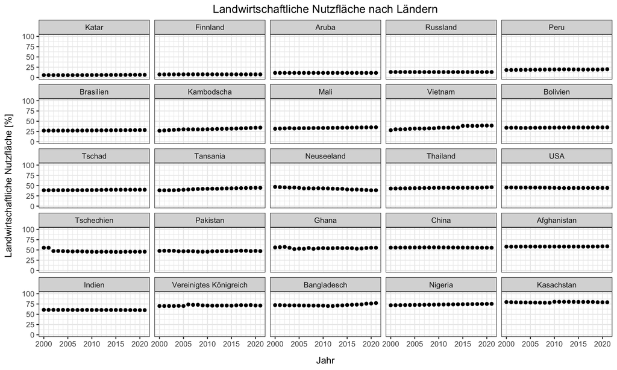

```
##    Min. 1st Qu.  Median    Mean 3rd Qu.    Max.
##   5.564  29.805  43.411  42.040  56.129  80.439
```

#### 1.4. Boxplot of agricultural land

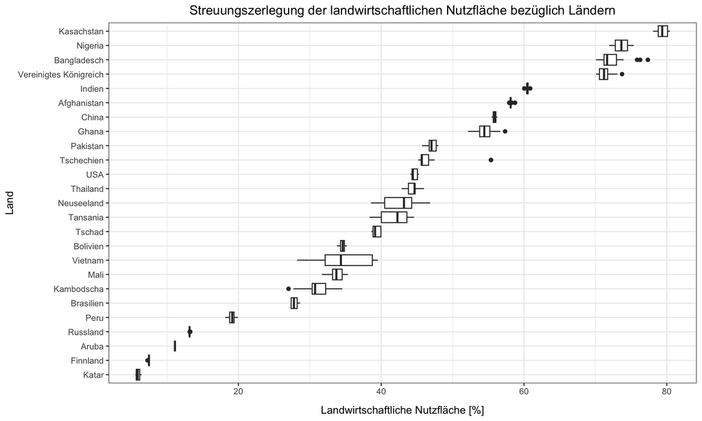

```
## Streuung zwischen den Ländern:  437.7944
```

In contrast to the CO2 emissions, the percentages of agricultural land have rather low variance within the countries. However, there are recognizable deviations between the countries, spanning from only five to up to eighty percent. As we operate on a capped percentage scale though, comparisons should be possible quite well.  
Moving on, we want to bring those two variables back together. For this purpose, analyzing the distribution of the collected data while disregarding the country-specific origin gives us the following cloud of data points. Note, that the CO2 emissions are displayed logarithmic to counter the expansive value disparity in the data.

#### 1.5. Scatter plot of interested variables

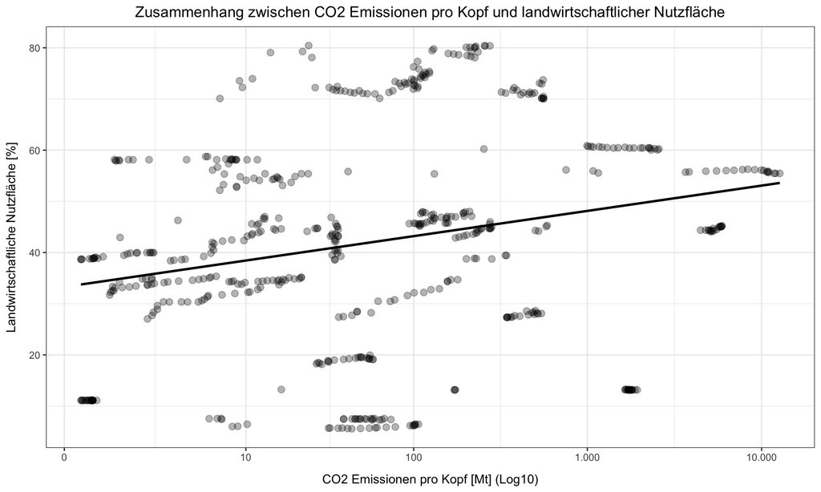

We can recognize a slightly positive linear trend between the variables. However, the development over time and the country-specification of observations are completely ignored. In order to take those factors back into consideration, we first distinguish among the countries by faceting our visualization for an in-depth comparison of the indicators for each country over time.

#### 1.6. Point-line plot of CO2 emissions with faceted countries and color scale

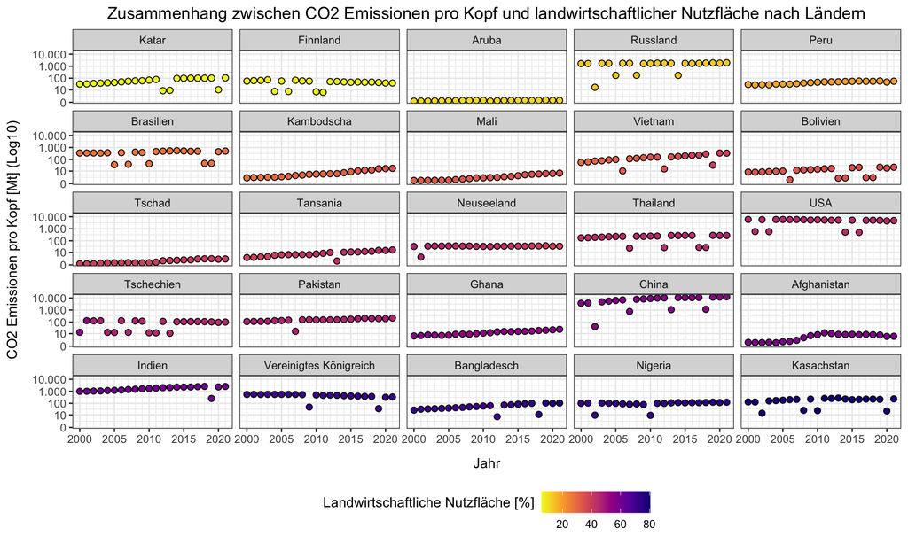

The chosen format of the scatter plot instead of line visualization attempts to counter the false entries for CO2 emissions, as for lines the error-caused outliers are displayed in a more extreme way leading us to scatters instead.  
However, the in ascending percentage of agricultural land sorted facets show no obvious connection between the two indicators, as the CO2 emissions are developing quite arbitrarily regardless of the associated percentage of agricultural land.

#### 1.7. Point-line plot of interested variables with faceted countries; normalized

To dig even further, we now adjust the data by normalizing the CO2 emissions within each country, letting us investigate relative changes on the same scale as the agricultural land.

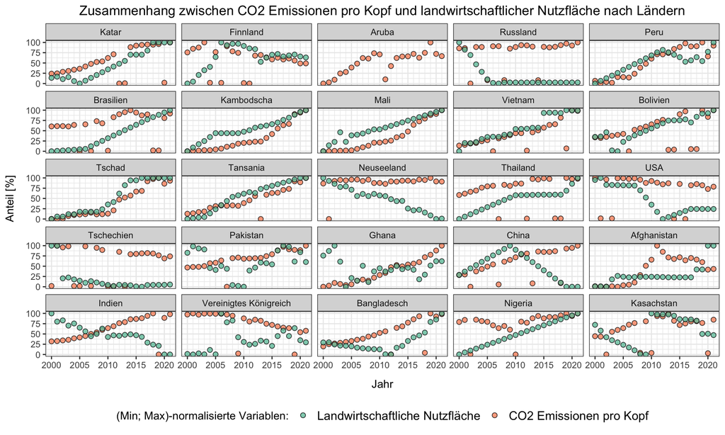